# Meeting Notes - June 24

Discussion of Maritimes environmental data access, June 24, 2020

B. Casault, E. Chisholm, C. Layton, C. Johnson, M. McMahon

## Meeting Minutes

### Discussion around Benoit’s document

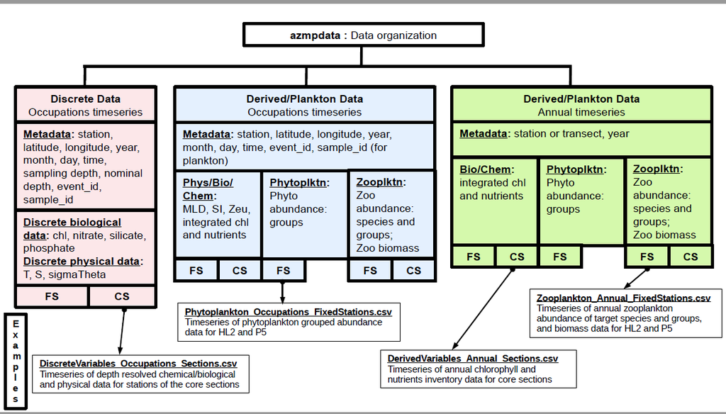

Figure 1. Organizational chart for structure of azmpdata

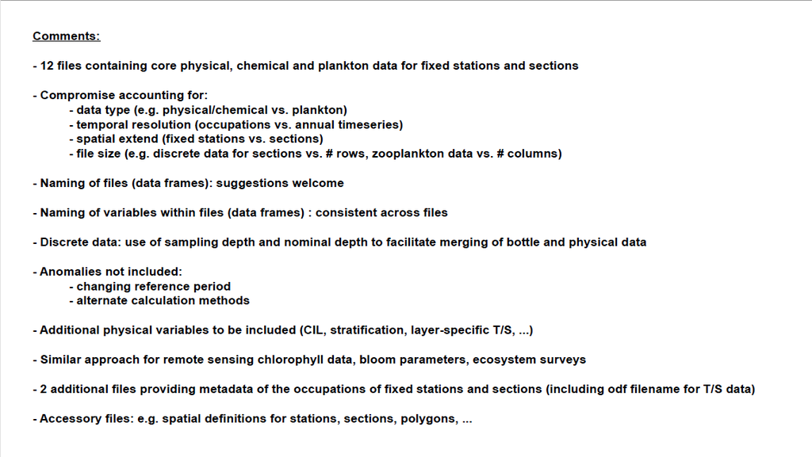

Figure 2. Comments from Benoit on organizational chart / azmpdata structure.

- The structure of azmpdata (fig 1) makes sense to all team members
- CIL and other non- depth-dependent variablesx will fit into derived/plankton category (fig 1)
  - This box may need to branch off to include broad scale shelf data metrics
  - This would also include climate metrics eg AMO (annual, broad scale metrics)
- Some variables will be listed as lower priority and structure can be expanded later to fit, but the structure should be robust enough to include future modifications
- Remote sensing products
  - want to avoid multivaR or other packages having to grab products from ftp servers
  - would fit best in blue data structure box (fig 1)
  - single values for statistical boxes, no sample IDs or event IDs may need work around
- There is a certain compromise on file size which is balanced well
- varibale naming scheme
  - would BODC or another standard vairable naming scheme be able to incorporate these metrics? likely only discrete..
  - There is large benefit in brevity of variable names
  - **EC will compile a list of variable names and circulate for discussion**
  - any ambiguity will be resolved in data documentation
  - should create look up table or style sheet
  - discrete vs derived variables should be clear from naming
  - look at intl standards from ICES, NOAA, BODC, etc
  - potential to translate between naming schemes if needed
- data frame naming scheme
  - using ‘matrix’
  - seperated by underscores
  - first part of name defines variable type : discrete, derived, zooplankton, phytoplankton
  - second part of name defines temporal scale: occupations, annual
  - third part of name defines spatial scale: stations, sections, broadscale
  - example name would be discrete_annual_stations.csv or derived_annual_broadscale.csv
- depth measures
  - sampling depth and nominal depth should be included with data
  - nominal depth is used for merging data
  - sampling depth is often required for calculations eg. integrated chl
- anomolies
  - will not be calculated in azmpdata
  - CL and BC both have anomoly scripts
  - **EC will gather scripts, compare and bring any discrepancies/conflicts to the group for attention**
  - **EC will create new anomoly function for multivaR**
- Data from Peter
  - Ice, NAO, AMO, RivSum
- Metadata files
  - BC has created metadata file for HL2, P5 should be a simple addition
  - these files contain ‘nuts and bolts’ detail info like sample IDs, precise lat and lon, event numbers etc
  - They also include ODF filenames for reference to TS
  - will be linked to data files through event and sample IDs
  - would be mostly used by behind the scenes processers such as Benoit, not necessary for average user
  - BC says they are easy to maintain
  - Will be included for completeness and in case the info is needed for more detailed analyses

### UPDATES

- CJ presented to working group
- CL and BC have been quite busy but hope to dedicate more time over the next month
- EC has been investigating questions from previous meetings and creating task list for multivaR
- BC shared RNOAA package, NOAA data access repo which team members will look at for any inspiration

### NEXT STEPS

- Assembling csv’s (BC/CL)
- AZMP search and vis code
- next meeting July 8th 2pm